### *Autor: Manuel Matías Corredoira de Soto*

#### Para esta tarea se ha pedido programar el descenso del gradiente desde python. Se debe explicar el procedimiento paso a paso para la realización del algoritmo que nos permitirá realizar el descenso.

#### Se realizará la tarea bajo el supuesto y la base de datos que nos ha siddo proporcionada para la realización de la tarea

### Los puntos más importantes para su realización son:

- **Size of Steps took in any direction = Ratio de aprendizaje**
- **Gadget tells you height = Función de coste**
- **The direction of your steps = Gradiente**

### Mostramos en términos gráficos y muy básicos cual será el objetivo de la tarea, minimizar la función de coste, lo cual iremos explicando paso a paso para su mejor compresión

```python
%%html
<img src = './data/punto_minimo.png' >
```

[figure not shown]

# Regresión logística y descenso del gradiente

#### Se supone que somos administradores de una universidad, y disponemos de 2 exámenes a modo de filtro para poder elegir a los alumnos que se consideran aptos de cara a relizar sus estudios en la misma. Disponemos de una base de datos con las notas de los ineteresados en cada una de las 2 pruebas y el dictamen respecto a su entrada o su denegación.

## Cargamos las librerías pertinentes

```python
import numpy as np
import pandas as pd
import seaborn as snimport
import matplotlib.pyplot as plt
```

#### Visualizamos las primeras observaciones de la base de datos y sus variables

```python
data = pd.read_csv('./data/4_1_data.csv')
data.head()
```

|  | score-1 | score-2 | label |
| --- | --- | --- | --- |
| 0 | 34.623660 | 78.024693 | 0 |
| 1 | 30.286711 | 43.894998 | 0 |
| 2 | 35.847409 | 72.902198 | 0 |
| 3 | 60.182599 | 86.308552 | 1 |
| 4 | 79.032736 | 75.344376 | 1 |

#### Cambiamos el nombre de las variables por si resulta necesario para trabajarlas de manera más sencilla.

```python
data= data.rename({'score-1':'score_1','score-2':'score_2'},axis=1)
data
```

|  | score_1 | score_2 | label |
| --- | --- | --- | --- |
| 0 | 34.623660 | 78.024693 | 0 |
| 1 | 30.286711 | 43.894998 | 0 |
| 2 | 35.847409 | 72.902198 | 0 |
| 3 | 60.182599 | 86.308552 | 1 |
| 4 | 79.032736 | 75.344376 | 1 |
| ... | ... | ... | ... |
| 95 | 83.489163 | 48.380286 | 1 |
| 96 | 42.261701 | 87.103851 | 1 |
| 97 | 99.315009 | 68.775409 | 1 |
| 98 | 55.340018 | 64.931938 | 1 |
| 99 | 74.775893 | 89.529813 | 1 |

100 rows × 3 columns

#### Comprobamos la existencia de posibles valores nulos en las columnas

```python
data.isnull().sum()                        # En este caso no se da la existencia de ninguna
```

```
score_1    0
score_2    0
label      0
dtype: int64
```

#### Pedimos una pequeña descripción de los datos.

```python
data.describe()
```

|  | score_1 | score_2 | label |
| --- | --- | --- | --- |
| count | 100.000000 | 100.000000 | 100.000000 |
| mean | 65.644274 | 66.221998 | 0.600000 |
| std | 19.458222 | 18.582783 | 0.492366 |
| min | 30.058822 | 30.603263 | 0.000000 |
| 25% | 50.919511 | 48.179205 | 0.000000 |
| 50% | 67.032988 | 67.682381 | 1.000000 |
| 75% | 80.212529 | 79.360605 | 1.000000 |
| max | 99.827858 | 98.869436 | 1.000000 |

```python
data.info()                             # Aquí podemos comprobar también la existencia de nulos, además del tipo de las variables ademas de otras cosas.
```

```
<class 'pandas.core.frame.DataFrame'>
RangeIndex: 100 entries, 0 to 99
Data columns (total 3 columns):
 #   Column   Non-Null Count  Dtype
---  ------   --------------  -----
 0   score_1  100 non-null    float64
 1   score_2  100 non-null    float64
 2   label    100 non-null    int64
dtypes: float64(2), int64(1)
memory usage: 2.5 KB
```

#### Creamos 2 objetos para distinguir dentro de la base en primer lugar las notas de las pruebas y a continuación los dictamenes marcados fruto de los resultados en las anteriores

```python
notas = data[['score_1', 'score_2']].values                          # Evaluación de las pruebas
dictamen = data['label'].values                                      # Elección final
```

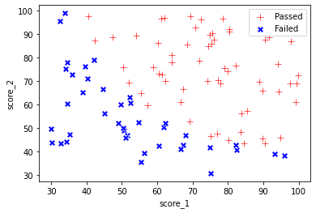

```python
passed = (dictamen == 1).reshape(100, 1)                            # Realizamos una nueva distinción, en este caso entre los
failed = (dictamen == 0).reshape(100, 1)                            #   alumnos aprobados y los suspensos.


# Ahora realizamos la graficación con las distinciones pautadas

ax = snimport.scatterplot(x = notas[passed[:, 0], 0],
                     y = notas[passed[:, 0], 1],
                     marker = "+",
                     color = "red",
                     s = 60)
snimport.scatterplot(x = notas[failed[:, 0], 0],
                y = notas[failed[:, 0], 1],
                marker = "X",
                color = "blue",
                s = 60)

ax.set(xlabel="score_1", ylabel="score_2")                           # Pedimos que marque cada uno de los ejes como nos parece.
ax.legend(["Passed", "Failed"])                                      # Marcamos que queremos que ponga en la leyenda.
plt.show();
```

#### En este caso disponemos de 2 variables respuesta que se corresponden con cada uno de los 2 exámenes. Los resultados de los mismos como hemos indicado arriba se pueden clasificar según su dictamen, solamente con 1 si son aceptados, o cero en caso contrario. Sin embargo uestro objetivo en este caso es minimizar la función de coste.

## Realizamos la función sigmoide.

#### Esta función se utiliza entre otras cosas para problemas de clasisficación binaria, que es nuestro caso por lo ya explicado. La funcion se utiliza para transformar regresiones lineales de modo que se puedan clasificar. Dan entre 0 y 1 de modo que se pueda calcular la probabilidad de que un hecho pueda llegar a suceder.

```python
def logistic_function(x):
    return 1/ (1 + np.exp(-x))
```

#### Realizamos ahora su representación gráfica:

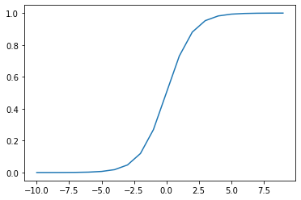

```python
u = np.arange(-10., 10., 1)
v = logistic_function(u)
plt.plot(u,v)
plt.show()
```

## Definición de la función de coste

#### definiremos la función sobre la cual buscaremos minimizar en la mayor medida posible. Se asocia a una regresió logítica y se define de la siguiente manera:

```python
%%html
<img src = './data/funcion_coste.png',style = 'width:5px' >
```

[figure not shown]

#### También vamos a incluir el gradiente, el cual se calculará y se incluirá dentro de la misma, para ello necesitaremos la realización de darivadas parciales sobra la funcvión anteriormente indicada.

#### La derivada nos indica la inclinación que se da dentro de la función. En nuestro caso se dirigirá de forma contraria al gradiente, ya que lo que buscamos es minimizar la función. 1º Calculamos los gradientes G mediante derivadas parciales G = ∂J(W)/∂W.

#### 2º actualizamos los pesos para cada iteración de modo que: theta = theta - learning_rate*G

#### 3º repetimos el proceso el número de veces que se considere pertinente, o bien hasta que se consiga la convergencia

```python
def compute_cost(theta, x, y):                                           # Damos los parámetros que utilizará la función
    m = len(y)                                                           # m será igual al número de observaciones de y
    y_pred = logistic_function(np.dot(x , theta))
    error = (y * np.log(y_pred)) + ((1 - y) * np.log(1 - y_pred))        # marcamos el error, que es la función de coste sin el término anterior al sumatorio
    cost = -1 / m * sum(error)                                           # Incluimos el coste, -1 / len(y) por la sum del error
    gradient = 1 / m * np.dot(x.transpose(), (y_pred - y))               # Juntamos ambas funciones para el gradiente
    return cost[0] , gradient                                            # Solicitamos ambos resultados
```

#### Realizaremos las primeras pautas para las mismas. Antes tendremos que marcar algunos puntos dentro de la base de datos para su posible realización efectiva

```python
mean_scores = np.mean(notas, axis=0)                        # Caalculamos la media de las notas
std_scores = np.std(notas, axis=0)                          # También su desviación típica
scores = (notas - mean_scores) / std_scores                 # Realizamos su respectiva normalización

rows = scores.shape[0]                                      # Pedimos tanto las filas como las columnas
cols = scores.shape[1]

X = np.append(np.ones((rows, 1)), scores, axis=1)           # Marcamos el término independiente
y = dictamen.reshape(rows, 1)                               # Ordenamos los resultados

theta_init = np.zeros((cols + 1, 1))                        # Marcamos parámetros uniciales para theta y también en el coste
cost, gradient = compute_cost(theta_init, X, y)

print("Primer coste : ", cost)                              # Solicitamos los resultados de cada uno
print("Gradiente : ", gradient)
```

```
Primer coste :  0.693147180559946
Gradiente :  [[-0.1       ]
 [-0.28122914]
 [-0.25098615]]
```

## Descenso del gradiente:

#### Se trata de un algoritmo de optimización utilizado para minimizar funciones. Se desplaza un número determinado de veces en función del número de iteraciones en sentido descendente al ponerle un signo negativo.

```python
def gradient_descent(x, y, theta, alpha, iterations):                    # Marcamos de qué dependerá la función
    costs = []
    for i in range(iterations):                                          # Queremos que recorra ambas funciones
        cost, gradient = compute_cost(theta, x, y)                       # Queremos que el coste se reduzca a medida que baja el gradiente
        theta -= (alpha * gradient)                                      # Queremos que theta recoja también alpha, que será nuestra tasa de aprendizaje. Por ello los multiplicaremos
        costs.append(cost)                                               # Queremos que estos se vayan añadiendo.
    return theta, costs
```

#### A continuación marcaremos las primeras cifras para obtener algunos resultados

```python
theta, costs = gradient_descent(X, y, theta_init, 0.7, 200)       # alpha se marcará entre 0 y 1 mientras que en las iteraciones marcaremos las que estimemos oportunas.
```

```python
print("Theta después del descendo del gradiente:", theta)         # Pedimos que nos imprima cada uno
print("Resultado del coste:", costs[-1])
```

```
Theta después del descendo del gradiente: [[1.39505009]
 [3.30786657]
 [3.06293714]]
Resultado del coste: 0.20698456963509276
```

#### Graficamos la convergencia

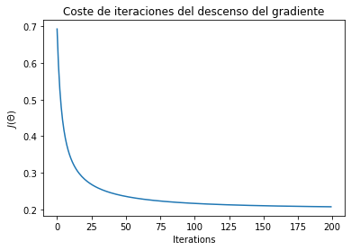

```python
plt.plot(costs)
plt.xlabel("Iterations")                                                 # Marcamos cada uno de los ejes
plt.ylabel("$J(\Theta)$")                                                # Marcamos el coste
plt.title("Coste de iteraciones del descenso del gradiente");            # Marcamos también el título
```

### Ahora vamos a ver el coste obtenido si disminuimos el valor de alpha manteniendo las iteraciones. Es decir, vamos a reducir el tamaño de los pasos que vamos a dar según la analogía que se utilizó en clase.

```python
theta, costs = gradient_descent(X, y, theta_init, 0.5, 200)
```

```python
print("Theta después del descendo del gradiente:", theta)
print("Resultado del coste:", costs[-1])
```

```
Theta después del descendo del gradiente: [[1.55689561]
 [3.64922981]
 [3.39279084]]
Resultado del coste: 0.20430018581593704
```

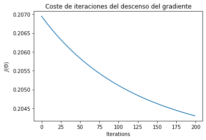

```python
plt.plot(costs)
plt.xlabel("Iterations")
plt.ylabel("$J(\Theta)$")
plt.title("Coste de iteraciones del descenso del gradiente");
```

#### Vemos que a medida que se dan más iteraciones, la 1º va siendo cada vez menos efectiva a la hora de minimizar el coste.

### A continuación vamos a subir el numero de iteracciones para ver si podemos disminuir el coste en mayor medida

```python
theta, costs = gradient_descent(X, y, theta_init, 0.5, 400)
```

```python
print("Theta después del descendo del gradiente:", theta)
print("Resultado del coste:", costs[-1])
```

```
Theta después del descendo del gradiente: [[1.67180359]
 [3.89329967]
 [3.62887189]]
Resultado del coste: 0.2035612415516126
```

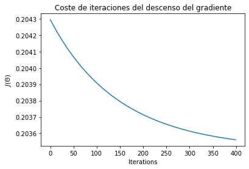

```python
plt.plot(costs)
plt.xlabel("Iterations")
plt.ylabel("$J(\Theta)$")
plt.title("Coste de iteraciones del descenso del gradiente");
```

#### Comprobamos como con el mismo alpha que en la anterior, y con más iteraciones es capaz de reducir la función. Hecho lógico ya que da más 'pasos' con el mismo alpha.

```python
theta, costs = gradient_descent(X, y, theta_init, 0.7, 400)
```

```python
print("Theta después del descendo del gradiente:", theta)
print("Resultado del coste:", costs[-1])
```

```
Theta después del descendo del gradiente: [[1.70950712]
 [3.97369679]
 [3.70666316]]
Resultado del coste: 0.2035000043386992
```

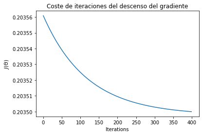

```python
plt.plot(costs)
plt.xlabel("Iterations")
plt.ylabel("$J(\Theta)$")
plt.title("Coste de iteraciones del descenso del gradiente");
```

### Referencias

*Gradient descent in Python. recuperado a partir de https://towardsdatascience.com/gradient-descent-in-python-a0d07285742f el dia 10/11/2020*

*Implement gradient descent in python. recuperado a partir de https://towardsdatascience.com/implement-gradient-descent-in-python-9b93ed7108d1 recuperado el dia 10/11/2020*

*Linear regression and gradient descent https://www.blueclaw.co.uk/2020/06/12/an-overview-of-linear-regression-and-gradient-descent-in-python-using-google-ads-data/ recuperado el día 1/11/2020*

*Tesis, Vazquez Morales J.A. https://www.fcfm.buap.mx/assets/docs/docencia/tesis/ma/JuanAntonioVazquezMorales.pdf recuperado de (p.29-32) el día 10/11/2020*

***Ejemplo del descenso del gradiente. https://github.com/lmntrixsid/Linear-and-Logistic-Regression-with-NumPy-and-Python/blob/master/Logistic_Regression_Completed.ipynb recuperado el día 11/10/2020